# Practical Machine Learning - Project

Guillaume Le Mener

May 24, 2015

# Executive Summary

This document presents the selection of a machine learning algorithm choseen to perform the task of predicting the Classe of physical activities based on data that represents the measurements of acceleration at different location on the body. After an exploration of the data, the selection of the algorithm is made by looking at the overall accuracy and the cross-validation of on 2 models suitable for classification.

# Configuration

This section provides information for reproductible research. Don’t forget to set the seed to the same value to reprodue the same results!

```r
version$platform
```

```
## [1] "x86_64-apple-darwin13.4.0"
```

```r
version$version.string
```

```
## [1] "R version 3.2.0 (2015-04-16)"
```

```r
#install.packages("caret")
#install.packages("randomForest")
#install.packages("rpart")
#install.packages("rpart.plot")
#install.packages("rattle")
#install.packages('e1071', dependencies=TRUE)
#install.packages("doMC", dependencies = TRUE)
require(caret)
require(randomForest)
require(rpart)
require(rattle)
require(rpart.plot)
require(e1071)
require(doMC)
set.seed(1234)
registerDoMC(cores=5)
```

# Exploration

## Downloading and loading the 2 data sets

```r
url_training <- "https://d396qusza40orc.cloudfront.net/predmachlearn/pml-training.csv"
url_testing <- "https://d396qusza40orc.cloudfront.net/predmachlearn/pml-testing.csv"

download.file(url=url_training, destfile="pml-training.csv", method="curl")
download.file(url=url_testing, destfile="pml-testing.csv", method="curl")

training = read.csv("pml-training.csv", na.strings=c("NA","#DIV/0!", ""))
testing = read.csv("pml-testing.csv", na.strings=c("NA","#DIV/0!", ""))
```

## Quick look at the data

First, checking if we have any NA values in the data sets since Machine Learning algorithmes are quiet sensitive to NA values.

```r
sum(is.na(training))
```

```
## [1] 1925102
```

```r
sum(is.na(testing))
```

```
## [1] 2000
```

Clearly, we do have NA values, let’s remove them.

```r
training <-training[,colSums(is.na(training)) == 0]
testing <-testing[,colSums(is.na(testing)) == 0]
```

Now, let’s look at the dimension of the 2 data sets.

```r
dim(training); dim(testing)
```

```
## [1] 19622    60
```

```
## [1] 20 60
```

```r
str(training)
```

```
## 'data.frame':    19622 obs. of  60 variables:
##  $ X                   : int  1 2 3 4 5 6 7 8 9 10 ...
##  $ user_name           : Factor w/ 6 levels "adelmo","carlitos",..: 2 2 2 2 2 2 2 2 2 2 ...
##  $ raw_timestamp_part_1: int  1323084231 1323084231 1323084231 1323084232 1323084232 1323084232 1323084232 1323084232 1323084232 1323084232 ...
##  $ raw_timestamp_part_2: int  788290 808298 820366 120339 196328 304277 368296 440390 484323 484434 ...
##  $ cvtd_timestamp      : Factor w/ 20 levels "02/12/2011 13:32",..: 9 9 9 9 9 9 9 9 9 9 ...
##  $ new_window          : Factor w/ 2 levels "no","yes": 1 1 1 1 1 1 1 1 1 1 ...
##  $ num_window          : int  11 11 11 12 12 12 12 12 12 12 ...
##  $ roll_belt           : num  1.41 1.41 1.42 1.48 1.48 1.45 1.42 1.42 1.43 1.45 ...
##  $ pitch_belt          : num  8.07 8.07 8.07 8.05 8.07 8.06 8.09 8.13 8.16 8.17 ...
##  $ yaw_belt            : num  -94.4 -94.4 -94.4 -94.4 -94.4 -94.4 -94.4 -94.4 -94.4 -94.4 ...
##  $ total_accel_belt    : int  3 3 3 3 3 3 3 3 3 3 ...
##  $ gyros_belt_x        : num  0 0.02 0 0.02 0.02 0.02 0.02 0.02 0.02 0.03 ...
##  $ gyros_belt_y        : num  0 0 0 0 0.02 0 0 0 0 0 ...
##  $ gyros_belt_z        : num  -0.02 -0.02 -0.02 -0.03 -0.02 -0.02 -0.02 -0.02 -0.02 0 ...
```

[output cut: 46 more lines]

The first 7 variables are not relevant to this project, so we are going to remove them.

```r
training  <-training[,-c(1:7)]
testing <-testing[,-c(1:7)]
```

Since we are going to predict the Classe variable, let’s take a look at it from a distribution point of view.

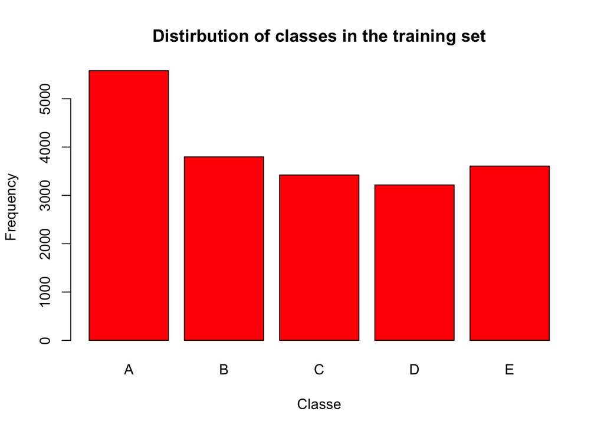

```r
plot(training$classe, main="Distirbution of classes in the training set", xlab="Classe", ylab="Frequency", col="red")
```

Almost a uniform level of frequencies accross the Classe excpet for A. D is the less frequent.

# Cross-Validation preparation (partioning)

To perform cross-validation we need to subset the our training data set in two sets. One of 75% of the training data set for training, and the remaining 25% for cross-validation. We use a random sampling without replacement.

```r
sub <- createDataPartition(y=training$classe, p=0.75, list=FALSE)
sub_training <- training[sub, ]
sub_testing <- training[-sub, ]
dim(sub_training); dim(sub_testing)
```

```
## [1] 14718    53
```

```
## [1] 4904   53
```

# First Model - Decision Tree

Let’s create first the Decision Tree model based on ‘rpart’ on the Class using all the variables avialable in the data set.

```r
first_model <- train(classe ~ ., data=sub_training, method="rpart")
```

```r
first_prediction <- predict(first_model, newdata=sub_testing)
```

[figure not shown]

```r
fancyRpartPlot(first_model$finalModel)
```

It looks like the model is not able to predict any of the D value.

```r
confusionMatrix(first_prediction, sub_testing$classe)
```

```
## Confusion Matrix and Statistics
##
##           Reference
## Prediction    A    B    C    D    E
##          A 1275  390  416  356  134
##          B   28  340   31  141  131
##          C   88  219  408  307  230
##          D    0    0    0    0    0
##          E    4    0    0    0  406
##
## Overall Statistics
##
##                Accuracy : 0.4953
##                  95% CI : (0.4812, 0.5094)
##     No Information Rate : 0.2845
##     P-Value [Acc > NIR] : < 2.2e-16
##
##                   Kappa : 0.3399
##  Mcnemar's Test P-Value : NA
##
## Statistics by Class:
##
##                      Class: A Class: B Class: C Class: D Class: E
## Sensitivity            0.9140  0.35827   0.4772   0.0000  0.45061
## Specificity            0.6307  0.91631   0.7916   1.0000  0.99900
## Pos Pred Value         0.4959  0.50671   0.3259      NaN  0.99024
## Neg Pred Value         0.9486  0.85613   0.8776   0.8361  0.88985
## Prevalence             0.2845  0.19352   0.1743   0.1639  0.18373
## Detection Rate         0.2600  0.06933   0.0832   0.0000  0.08279
## Detection Prevalence   0.5243  0.13683   0.2553   0.0000  0.08361
## Balanced Accuracy      0.7723  0.63729   0.6344   0.5000  0.72481
```

# Seconf Model - Random Forest

```r
second_model <- train(classe ~ ., data=sub_training, method="rf", trControl=trainControl(method="cv"),number=3)
```

```r
second_prediction <- predict(second_model, newdata=sub_testing)
confusionMatrix(second_prediction, sub_testing$classe)
```

```
## Confusion Matrix and Statistics
##
##           Reference
## Prediction    A    B    C    D    E
##          A 1392    3    0    0    0
##          B    3  946   15    0    0
##          C    0    0  838   10    0
##          D    0    0    2  794    0
##          E    0    0    0    0  901
##
## Overall Statistics
##
##                Accuracy : 0.9933
##                  95% CI : (0.9906, 0.9954)
##     No Information Rate : 0.2845
##     P-Value [Acc > NIR] : < 2.2e-16
##
##                   Kappa : 0.9915
##  Mcnemar's Test P-Value : NA
##
## Statistics by Class:
##
##                      Class: A Class: B Class: C Class: D Class: E
## Sensitivity            0.9978   0.9968   0.9801   0.9876   1.0000
## Specificity            0.9991   0.9954   0.9975   0.9995   1.0000
## Pos Pred Value         0.9978   0.9813   0.9882   0.9975   1.0000
## Neg Pred Value         0.9991   0.9992   0.9958   0.9976   1.0000
## Prevalence             0.2845   0.1935   0.1743   0.1639   0.1837
## Detection Rate         0.2838   0.1929   0.1709   0.1619   0.1837
## Detection Prevalence   0.2845   0.1966   0.1729   0.1623   0.1837
## Balanced Accuracy      0.9985   0.9961   0.9888   0.9935   1.0000
```

The second model performs very well. Accuracy is 0.9933 with a very good confidence interval (95% CI).

# Submission

```r
final <- predict(second_model, newdata=testing)
final
```

```
##  [1] B A B A A E D B A A B C B A E E A B B B
## Levels: A B C D E
```